# Linear Regression

19/01/2022

## Introduction

In this tutorial, we will look at the ways, you can perform a linear regression with R. We will make use of the earnings data, found in the data folder (data/Earnings.csv). This data set is from an american national survey in 1990 with 1816 respondents. Let’s load in the data and have a look at the variables

```r
library(tidyverse)

earn <- read_csv('data/Earnings.csv')

glimpse(earn)
```

```
## Rows: 1,816
## Columns: 15
## $ height           <dbl> 74, 66, 64, 65, 63, 68, 63, 64, 62, 73, 72, 72, 72, 7~
## $ weight           <dbl> 210, 125, 126, 200, 110, 165, 190, 125, 200, 230, 176~
## $ male             <dbl> 1, 0, 0, 0, 0, 0, 0, 0, 0, 1, 1, 1, 1, 1, 0, 1, 1, 1,~
## $ earn             <dbl> 50000, 60000, 30000, 25000, 50000, 62000, 51000, 9000~
## $ earnk            <dbl> 50.00, 60.00, 30.00, 25.00, 50.00, 62.00, 51.00, 9.00~
## $ ethnicity        <chr> "White", "White", "White", "White", "Other", "Black",~
## $ education        <dbl> 16, 16, 16, 17, 16, 18, 17, 15, 12, 17, 15, NA, 12, 1~
## $ mother_education <dbl> 16, 16, 16, 17, 16, 18, 17, 15, 12, 17, 15, 99, 12, 1~
## $ father_education <dbl> 16, 16, 16, NA, 16, 18, 17, 15, 12, 17, 15, 99, 12, N~
## $ walk             <dbl> 3, 6, 8, 8, 5, 1, 3, 7, 2, 7, 8, 1, 1, 4, 7, 7, 6, 4,~
## $ exercise         <dbl> 3, 5, 1, 1, 6, 1, 1, 4, 2, 1, 1, 1, 2, 1, 4, 4, 5, 6,~
## $ smokenow         <dbl> 2, 1, 2, 2, 2, 2, 2, 1, 2, 1, 2, 2, 2, 2, 2, 2, 2, 2,~
## $ tense            <dbl> 0, 0, 1, 0, 0, 2, 4, 4, 0, 0, 0, 0, 1, 0, 2, 0, 2, 0,~
## $ angry            <dbl> 0, 0, 1, 0, 0, 2, 4, 4, 0, 0, 0, 0, 1, 0, 2, 0, 2, 0,~
## $ age              <dbl> 45, 58, 29, 57, 91, 54, 39, 26, 49, 46, 21, 53, 26, 6~
```

We see there are 1816 observations and 15 variables in the data. It’s good practice to get a feel for what is contained in the data through descriptive statistics.

```r
summary(earn)
```

```
##      height          weight           male             earn
##  Min.   :57.00   Min.   : 80.0   Min.   :0.0000   Min.   :     0
##  1st Qu.:64.00   1st Qu.:130.0   1st Qu.:0.0000   1st Qu.:  6000
##  Median :66.00   Median :150.0   Median :0.0000   Median : 16000
##  Mean   :66.57   Mean   :156.3   Mean   :0.3717   Mean   : 21147
##  3rd Qu.:69.25   3rd Qu.:180.0   3rd Qu.:1.0000   3rd Qu.: 27000
##  Max.   :82.00   Max.   :342.0   Max.   :1.0000   Max.   :400000
##                  NA's   :27
##      earnk         ethnicity           education     mother_education
##  Min.   :  0.00   Length:1816        Min.   : 2.00   Min.   : 3.00
##  1st Qu.:  6.00   Class :character   1st Qu.:12.00   1st Qu.:12.00
##  Median : 16.00   Mode  :character   Median :12.00   Median :13.00
##  Mean   : 21.15                      Mean   :13.24   Mean   :13.61
##  3rd Qu.: 27.00                      3rd Qu.:15.00   3rd Qu.:16.00
##  Max.   :400.00                      Max.   :18.00   Max.   :99.00
##                                      NA's   :2       NA's   :244
##  father_education      walk          exercise        smokenow
##  Min.   : 3.00    Min.   :1.000   Min.   :1.000   Min.   :1.000
##  1st Qu.:12.00    1st Qu.:3.000   1st Qu.:1.000   1st Qu.:1.000
##  Median :13.00    Median :6.000   Median :2.000   Median :2.000
##  Mean   :13.65    Mean   :5.303   Mean   :3.049   Mean   :1.745
##  3rd Qu.:16.00    3rd Qu.:8.000   3rd Qu.:5.000   3rd Qu.:2.000
##  Max.   :99.00    Max.   :8.000   Max.   :7.000   Max.   :2.000
##  NA's   :295                                      NA's   :1
##      tense           angry            age
##  Min.   :0.000   Min.   :0.000   Min.   :18.00
##  1st Qu.:0.000   1st Qu.:0.000   1st Qu.:29.00
##  Median :0.000   Median :0.000   Median :39.00
##  Mean   :1.421   Mean   :1.421   Mean   :42.93
##  3rd Qu.:2.000   3rd Qu.:2.000   3rd Qu.:56.00
##  Max.   :7.000   Max.   :7.000   Max.   :91.00
##  NA's   :1       NA's   :1
```

### Summarizing missing data

We will write a function to count the number of missing values in a vector and apply it to each variable

```r
count_missing <- function(x) {

  return(sum(is.na(x)))

}

earn %>%
  summarize_all(count_missing) %>%
  DT::datatable(options = list(scrollX = T))
```

|  | height | weight | male | earn | earnk | ethnicity | education | mother_education | father_education | walk | exercise | smokenow | tense | angry | age |
| --- | --- | --- | --- | --- | --- | --- | --- | --- | --- | --- | --- | --- | --- | --- | --- |
| 1 | 0 | 27 | 0 | 0 | 0 | 0 | 2 | 244 | 295 | 0 | 0 | 1 | 1 | 1 | 0 |

### Counts and proportions

We often want to produce counts and proportions for variables as well.

```r
categorical_variables <- c("ethnicity",
                           "education",
                           "mother_education",
                           "father_education",
                           "walk",
                           "exercise",
                           "smokenow",
                           "tense")


count_data_string <- function(data, string_var) {
  data %>%
    count(!!rlang::sym(string_var)) %>%
    mutate(proportion = n/sum(n))
}


count_data_var <- function(data, count_var) {
  data %>%
    count({{ count_var }}) %>%
    mutate(proportion = n/sum(n))
}


tabs <- lapply(categorical_variables, function(x) {
  count_data_string(earn, x)
})

tabs
```

```
## [[1]]
## # A tibble: 4 x 3
##   ethnicity     n proportion
##   <chr>     <int>      <dbl>
## 1 Black       180     0.0991
## 2 Hispanic    104     0.0573
## 3 Other        38     0.0209
## 4 White      1494     0.823
##
## [[2]]
## # A tibble: 18 x 3
##    education     n proportion
##        <dbl> <int>      <dbl>
##  1         2     1   0.000551
##  2         3     1   0.000551
##  3         4     2   0.00110
##  4         5     7   0.00385
##  5         6    13   0.00716
##  6         7     7   0.00385
##  7         8    54   0.0297
##  8         9    36   0.0198
##  9        10    49   0.0270
## 10        11    61   0.0336
## 11        12   687   0.378
## 12        13   142   0.0782
## 13        14   234   0.129
## 14        15    85   0.0468
## 15        16   235   0.129
## 16        17    84   0.0463
## 17        18   116   0.0639
## 18        NA     2   0.00110
##
## [[3]]
## # A tibble: 18 x 3
##    mother_education     n proportion
##               <dbl> <int>      <dbl>
##  1                3     1   0.000551
##  2                4     1   0.000551
##  3                5     2   0.00110
##  4                6     3   0.00165
```

[output cut: 69 more lines]

```
## 3       NA     1   0.000551
##
## [[8]]
## # A tibble: 9 x 3
##   tense     n proportion
##   <dbl> <int>      <dbl>
## 1     0   994   0.547
## 2     1   259   0.143
## 3     2   174   0.0958
## 4     3   111   0.0611
## 5     4    64   0.0352
## 6     5    45   0.0248
## 7     6    17   0.00936
## 8     7   151   0.0831
## 9    NA     1   0.000551
```

### Table one

Sometimes we want to summarize all of our descriptive values in a single table. The `tableone` package is great for this purpose.

```r
library(tableone)
# all data as continuous
CreateTableOne(data = earn)
```

```
##
##                                Overall
##   n                                1816
##   height (mean (SD))              66.57 (3.83)
##   weight (mean (SD))             156.31 (34.62)
##   male (mean (SD))                 0.37 (0.48)
##   earn (mean (SD))             21147.30 (22531.77)
##   earnk (mean (SD))               21.15 (22.53)
##   ethnicity (%)
##      Black                          180 ( 9.9)
##      Hispanic                       104 ( 5.7)
##      Other                           38 ( 2.1)
##      White                         1494 (82.3)
##   education (mean (SD))           13.24 (2.56)
##   mother_education (mean (SD))    13.61 (3.22)
##   father_education (mean (SD))    13.65 (3.25)
##   walk (mean (SD))                 5.30 (2.60)
##   exercise (mean (SD))             3.05 (2.32)
##   smokenow (mean (SD))             1.75 (0.44)
##   tense (mean (SD))                1.42 (2.16)
##   angry (mean (SD))                1.42 (2.16)
##   age (mean (SD))                 42.93 (17.16)
```

```r
# use categorical variables
CreateTableOne(data = earn, factorVars = categorical_variables)
```

```
##
##                        Overall
##   n                        1816
##   height (mean (SD))      66.57 (3.83)
##   weight (mean (SD))     156.31 (34.62)
##   male (mean (SD))         0.37 (0.48)
##   earn (mean (SD))     21147.30 (22531.77)
##   earnk (mean (SD))       21.15 (22.53)
##   ethnicity (%)
##      Black                  180 ( 9.9)
##      Hispanic               104 ( 5.7)
##      Other                   38 ( 2.1)
##      White                 1494 (82.3)
##   education (%)
##      2                        1 ( 0.1)
```

[output cut: 81 more lines]

## Regression methods in R

We will slowly build up a regression model using some common functions.

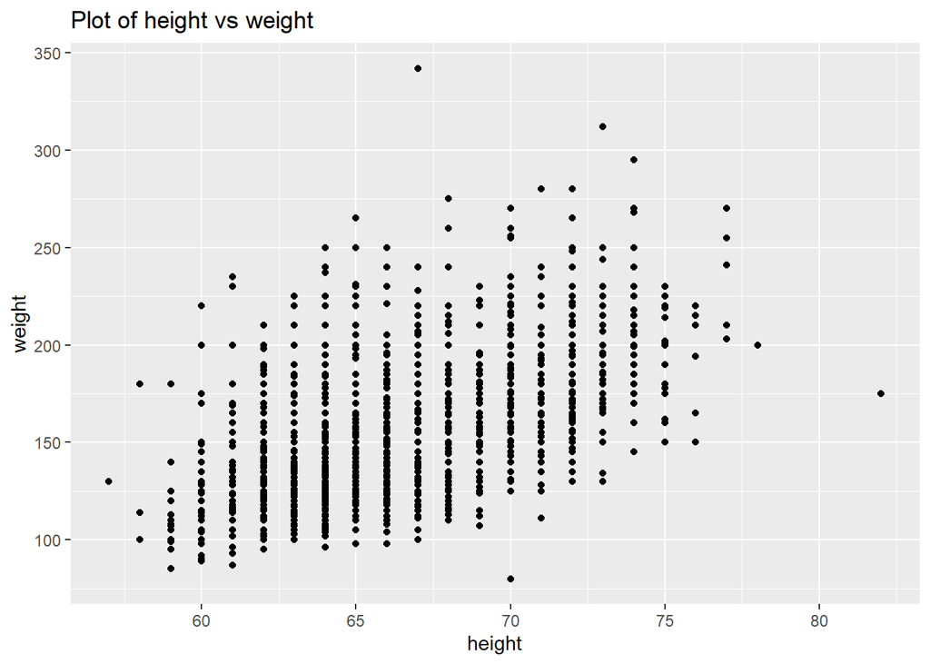

```r
earn %>%
  ggplot(aes(height, weight)) +
  geom_point() +
  ggtitle("Plot of height vs weight")
```

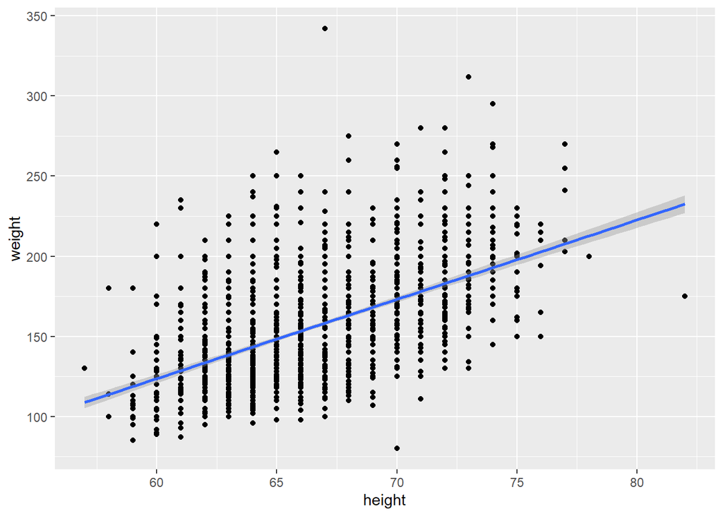

```r
earn %>%
  ggplot(aes(height, weight)) +
  geom_point() +
  geom_smooth(method="lm")
```

```r
  ggtitle("Plot of height vs weight",
          subtitle = "With regression line")
```

```
## $title
## [1] "Plot of height vs weight"
##
## $subtitle
## [1] "With regression line"
##
## attr(,"class")
## [1] "labels"
```

### Simple linear model

There are several ways of running a regression model in R. We can use the base `lm` method, or the `glm` method which we will look at in detail when we make generalized linear models.

```r
# method 1 : linear model
slm <- lm(weight ~ height, data = earn)

print(summary(slm))
```

```
##
## Call:
## lm(formula = weight ~ height, data = earn)
##
## Residuals:
##     Min      1Q  Median      3Q     Max
## -93.170 -18.525  -3.575  11.931 183.678
##
## Coefficients:
##              Estimate Std. Error t value Pr(>|t|)
## (Intercept) -173.2865    11.9043  -14.56   <2e-16 ***
## height         4.9494     0.1785   27.73   <2e-16 ***
## ---
## Signif. codes:  0 '***' 0.001 '**' 0.01 '*' 0.05 '.' 0.1 ' ' 1
##
## Residual standard error: 28.95 on 1787 degrees of freedom
##   (27 observations deleted due to missingness)
## Multiple R-squared:  0.3009, Adjusted R-squared:  0.3005
## F-statistic: 769.1 on 1 and 1787 DF,  p-value: < 2.2e-16
```

```r
# method 2: genearlized linear model
slm2 <- glm(weight ~ height, family = "gaussian", data = earn)

print(summary(slm2))
```

```
##
## Call:
## glm(formula = weight ~ height, family = "gaussian", data = earn)
##
## Deviance Residuals:
##     Min       1Q   Median       3Q      Max
## -93.170  -18.525   -3.575   11.931  183.678
##
## Coefficients:
##              Estimate Std. Error t value Pr(>|t|)
## (Intercept) -173.2865    11.9043  -14.56   <2e-16 ***
## height         4.9494     0.1785   27.73   <2e-16 ***
## ---
## Signif. codes:  0 '***' 0.001 '**' 0.01 '*' 0.05 '.' 0.1 ' ' 1
##
## (Dispersion parameter for gaussian family taken to be 838.2426)
##
##     Null deviance: 2142633  on 1788  degrees of freedom
## Residual deviance: 1497940  on 1787  degrees of freedom
##   (27 observations deleted due to missingness)
## AIC: 17123
##
## Number of Fisher Scoring iterations: 2
```

Nice printing methods

```r
# method 1 : linear model
sjPlot::tab_model(slm)
```

|  | weight |  |  |
| --- | --- | --- | --- |
| Predictors | Estimates | CI | p |
| (Intercept) | -173.29 | -196.63 – -149.94 | **<0.001** |
| height | 4.95 | 4.60 – 5.30 | **<0.001** |
| Observations | 1789 |  |  |
| R<sup>2</sup> / R<sup>2</sup> adjusted | 0.301 / 0.300 |  |  |

```r
# method 2: genearlized linear model
sjPlot::tab_model(slm2)
```

|  | weight |  |  |
| --- | --- | --- | --- |
| Predictors | Estimates | CI | p |
| (Intercept) | -173.29 | -196.62 – -149.95 | **<0.001** |
| height | 4.95 | 4.60 – 5.30 | **<0.001** |
| Observations | 1789 |  |  |
| R<sup>2</sup> | 0.301 |  |  |

### Generate a simple prediction manually

Let’s generate a prediction for someone who is 55 inches tall

```r
new_height <- 55

# extract the coefficients
coefs_slm <- coef(slm)
print(coefs_slm)
```

```
## (Intercept)      height
##  -173.28645     4.94938
```

```r
# calculate prediction
predicted_weight <- coefs_slm[1] + coefs_slm[2]*new_height

print(predicted_weight)
```

```
## (Intercept)
##    98.92946
```

### Generate simple prediction with predict method

We can also use the `predict` method to generate a prediction. We need to pass a data.frame containing the new predictor variables.

```r
new_height <- data.frame(height=55)


# calculate prediction
predicted_weight <- predict(slm, new_height)

print(predicted_weight)
```

```
##        1
## 98.92946
```

```r
# calculate prediction with the glm object
predicted_weight <- predict(slm2, new_height)
```

### Working with `lm` objects

When working with a new object in R, it’s good practice to look at its structure and see what is available to you. The functions `str` and `names` are perfect for this.

```r
# the object structure
print(str(slm))
```

```
## List of 13
##  $ coefficients : Named num [1:2] -173.29 4.95
##   ..- attr(*, "names")= chr [1:2] "(Intercept)" "height"
##  $ residuals    : Named num [1:1789] 17 -28.4 -17.5 51.6 -28.5 ...
##   ..- attr(*, "names")= chr [1:1789] "1" "2" "3" "4" ...
##  $ effects      : Named num [1:1789] -6611.2 802.9 -17.4 51.5 -28.3 ...
##   ..- attr(*, "names")= chr [1:1789] "(Intercept)" "height" "" "" ...
##  $ rank         : int 2
##  $ fitted.values: Named num [1:1789] 193 153 143 148 139 ...
##   ..- attr(*, "names")= chr [1:1789] "1" "2" "3" "4" ...
##  $ assign       : int [1:2] 0 1
##  $ qr           :List of 5
##   ..$ qr   : num [1:1789, 1:2] -42.2966 0.0236 0.0236 0.0236 0.0236 ...
##   .. ..- attr(*, "dimnames")=List of 2
##   .. .. ..$ : chr [1:1789] "1" "2" "3" "4" ...
##   .. .. ..$ : chr [1:2] "(Intercept)" "height"
##   .. ..- attr(*, "assign")= int [1:2] 0 1
##   ..$ qraux: num [1:2] 1.02 1
##   ..$ pivot: int [1:2] 1 2
##   ..$ tol  : num 1e-07
##   ..$ rank : int 2
##   ..- attr(*, "class")= chr "qr"
##  $ df.residual  : int 1787
##  $ na.action    : 'omit' Named int [1:27] 45 51 234 251 380 434 441 559 613 614 ...
##   ..- attr(*, "names")= chr [1:27] "45" "51" "234" "251" ...
##  $ xlevels      : Named list()
##  $ call         : language lm(formula = weight ~ height, data = earn)
##  $ terms        :Classes 'terms', 'formula'  language weight ~ height
##   .. ..- attr(*, "variables")= language list(weight, height)
##   .. ..- attr(*, "factors")= int [1:2, 1] 0 1
##   .. .. ..- attr(*, "dimnames")=List of 2
##   .. .. .. ..$ : chr [1:2] "weight" "height"
##   .. .. .. ..$ : chr "height"
##   .. ..- attr(*, "term.labels")= chr "height"
##   .. ..- attr(*, "order")= int 1
##   .. ..- attr(*, "intercept")= int 1
##   .. ..- attr(*, "response")= int 1
##   .. ..- attr(*, ".Environment")=<environment: R_GlobalEnv>
##   .. ..- attr(*, "predvars")= language list(weight, height)
##   .. ..- attr(*, "dataClasses")= Named chr [1:2] "numeric" "numeric"
##   .. .. ..- attr(*, "names")= chr [1:2] "weight" "height"
##  $ model        :'data.frame':   1789 obs. of  2 variables:
##   ..$ weight: num [1:1789] 210 125 126 200 110 165 190 125 200 230 ...
##   ..$ height: num [1:1789] 74 66 64 65 63 68 63 64 62 73 ...
##   ..- attr(*, "terms")=Classes 'terms', 'formula'  language weight ~ height
##   .. .. ..- attr(*, "variables")= language list(weight, height)
##   .. .. ..- attr(*, "factors")= int [1:2, 1] 0 1
##   .. .. .. ..- attr(*, "dimnames")=List of 2
##   .. .. .. .. ..$ : chr [1:2] "weight" "height"
##   .. .. .. .. ..$ : chr "height"
##   .. .. ..- attr(*, "term.labels")= chr "height"
##   .. .. ..- attr(*, "order")= int 1
##   .. .. ..- attr(*, "intercept")= int 1
##   .. .. ..- attr(*, "response")= int 1
##   .. .. ..- attr(*, ".Environment")=<environment: R_GlobalEnv>
##   .. .. ..- attr(*, "predvars")= language list(weight, height)
##   .. .. ..- attr(*, "dataClasses")= Named chr [1:2] "numeric" "numeric"
##   .. .. .. ..- attr(*, "names")= chr [1:2] "weight" "height"
##   ..- attr(*, "na.action")= 'omit' Named int [1:27] 45 51 234 251 380 434 441 559 613 614 ...
##   .. ..- attr(*, "names")= chr [1:27] "45" "51" "234" "251" ...
##  - attr(*, "class")= chr "lm"
## NULL
```

```r
# the object names
print(names(slm))
```

```
##  [1] "coefficients"  "residuals"     "effects"       "rank"
##  [5] "fitted.values" "assign"        "qr"            "df.residual"
##  [9] "na.action"     "xlevels"       "call"          "terms"
## [13] "model"
```

we can see for example that this object contains both the fitted values and residuals. We could calculate these by hand if we wanted and verify that they hold the same values as what is in the model object.

```r
# generating fitted values (removing NA's for comparison)
fitted_values_calc <- predict(slm, earn %>% filter(!is.na(height), !is.na(weight)))

# comparing the calculation against the vector stored in the model object
all.equal(as.vector(fitted_values_calc), as.vector(slm$fitted.values))
```

```
## [1] TRUE
```

```r
# generating residuals
y <- earn %>%
  filter(!is.na(height), !is.na(weight)) %>%
  pull(weight)
residuals_calc <- y - fitted_values_calc
all.equal(as.vector(residuals_calc), as.vector(slm$residuals))
```

```
## [1] TRUE
```

### Extracting model fit

```r
model_summary <- summary(slm)


# r squared
model_summary$r.squared
```

```
## [1] 0.3008885
```

```r
# adjusted r-squred
model_summary$adj.r.squared
```

```
## [1] 0.3004973
```

```r
# f statistic
model_summary$fstatistic
```

```
##     value     numdf     dendf
##  769.1017    1.0000 1787.0000
```

We can also extract the model AIC using the `AIC()` function and BIC using the `BIC()` function

```r
AIC(slm)
```

```
## [1] 17123.27
```

```r
BIC(slm)
```

```
## [1] 17139.74
```

## Simulating data for regression

Often we want to simulate data to model assumptions we may have about a potential project. Here I demonstrate how to simulate data for the following model

$$Y = 25 + 7.2*x + \epsilon, \epsilon \sim N(0, 15)$$

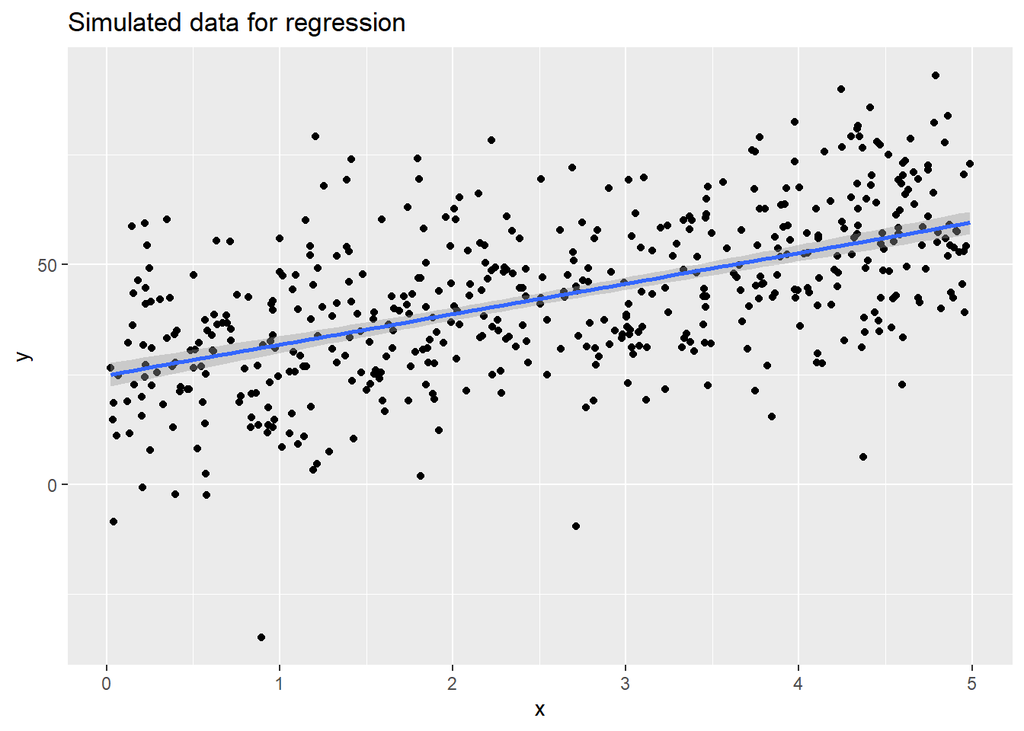

```r
simulate_simple_reg_data = function(sample_size = 500,
                                    intercept = 0,
                                    slope = 0,
                                    sigma = 0) {
  x = runif(n = sample_size) * 5
  y = intercept + slope * x + rnorm(n = sample_size, mean = 0, sd = sigma)
  data.frame(x, y)
}

sim_df <- simulate_simple_reg_data(intercept = 25, slope = 7.2, sigma = 15)

sim_df %>%
  ggplot(aes(x, y)) +
  geom_point() +
  geom_smooth(method="lm") +
  labs(title = "Simulated data for regression")
```

### Residuals vs fitted

Let’s look at a residual vs fitted data plot to check for contstant variance

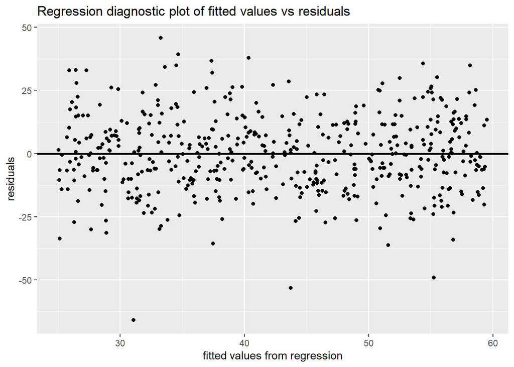

```r
model_fit <- lm(y~ x, data = sim_df)

sim_df %>%
  mutate(fitted_values = predict(model_fit, sim_df),
         residuals = y - fitted_values) %>%
  ggplot(aes(fitted_values, residuals)) +
  geom_point() +
  geom_hline(yintercept = 0, size = 1) +
  labs(x = "fitted values from regression",
       y = 'residuals',
       title = "Regression diagnostic plot of fitted values vs residuals")
```

What are we looking at in this plot?

First, the residuals should be centered around the horizontal line at 0. If this is the case, then the linearity assumption likely holds true. The second thing we would like to see is that the spread of the points is even for every value of x.

What would a plot with uneven variance look like? Let’s simuate data like above, but let’s make the variance = $x^2$.

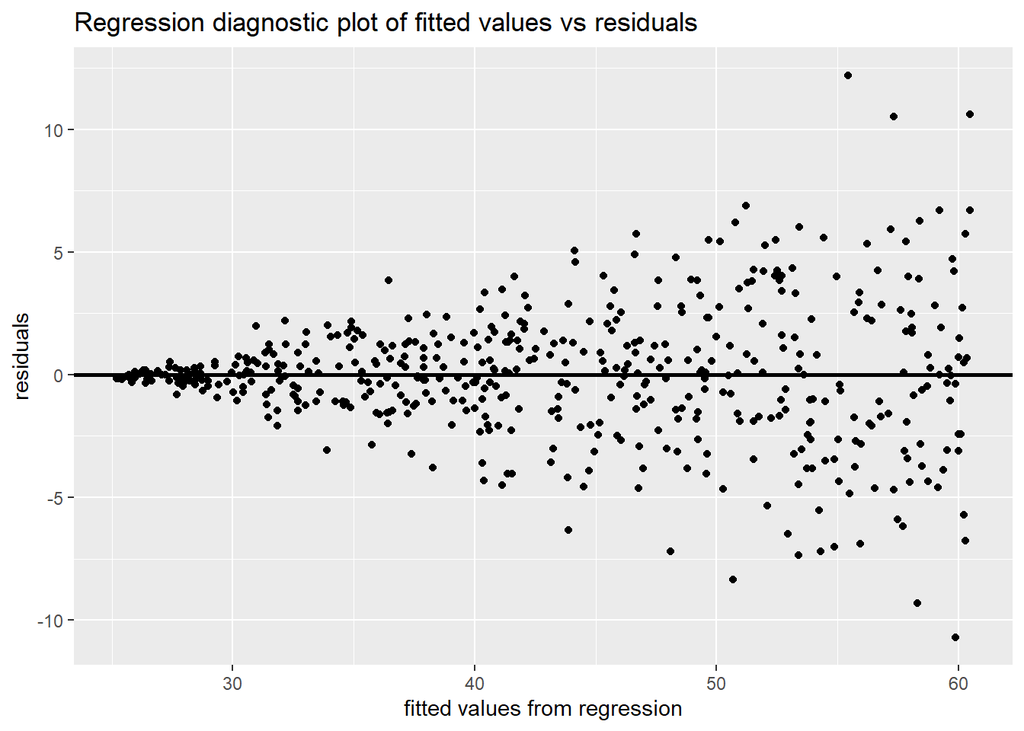

```r
simulate_unequal_var_data = function(sample_size = 500,
                                    intercept = 0,
                                    slope = 0) {
  x = runif(n = sample_size) * 5
  y = intercept + slope * x + rnorm(n = sample_size, mean = 0, sd = x)
  data.frame(x, y)
}

sim_bad_var_df <- simulate_unequal_var_data(intercept = 25, slope = 7.2)

model_fit_enequal_var <- lm(y~ x, data = sim_bad_var_df)

sim_bad_var_df %>%
  mutate(fitted_values = predict(model_fit_enequal_var, sim_bad_var_df),
         residuals = y - fitted_values) %>%
  ggplot(aes(fitted_values, residuals)) +
  geom_point() +
  geom_hline(yintercept = 0, size = 1) +
  labs(x = "fitted values from regression",
       y = 'residuals',
       title = "Regression diagnostic plot of fitted values vs residuals")
```

How about a model violating the linearity assumption? We can simulate that as well

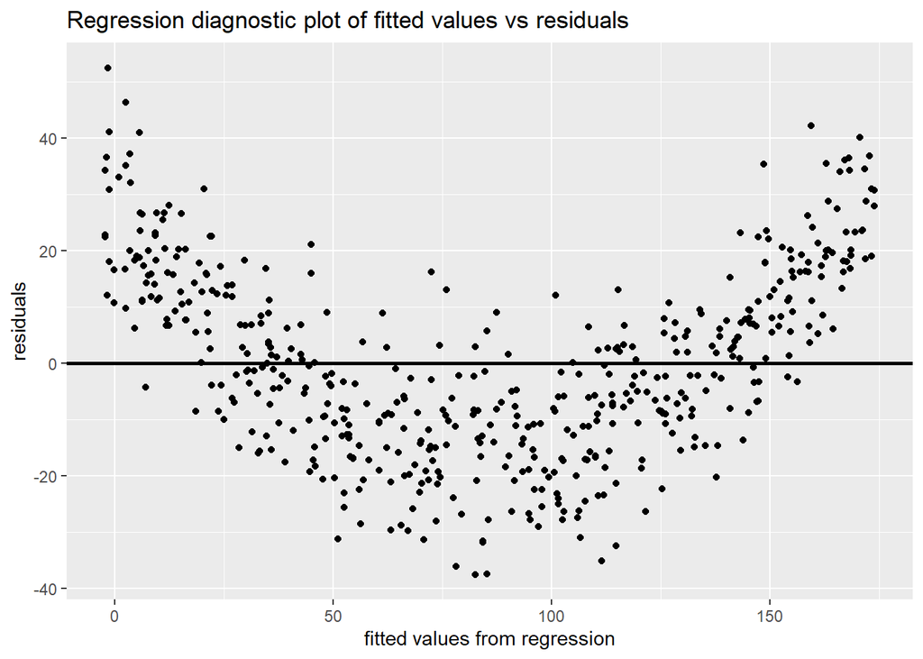

```r
simulate_nonlinear_data = function(sample_size = 500,
                                    intercept = 0,
                                    slope = 0,
                                   sigma = 1) {
  x = runif(n = sample_size) * 5
  y = intercept + slope * x^2 + rnorm(n = sample_size, mean = 0, sd = sigma)
  data.frame(x, y)
}

sim_nonlinear_df <- simulate_nonlinear_data(intercept = 25, slope = 7.2, sigma = 10)

model_fit_nonlin <- lm(y~ x, data = sim_nonlinear_df)

sim_nonlinear_df %>%
  mutate(fitted_values = predict(model_fit_nonlin, sim_nonlinear_df),
         residuals = y - fitted_values) %>%
  ggplot(aes(fitted_values, residuals)) +
  geom_point() +
  geom_hline(yintercept = 0, size = 1) +
  labs(x = "fitted values from regression",
       y = 'residuals',
       title = "Regression diagnostic plot of fitted values vs residuals")
```

Here we see that the variance spread looks reasonable, but there is clearly a non-linear relationship between the x and y variables.

### Residual and QQ plots

We can also look at histograms of residuals, and QQ plots to check for normality.

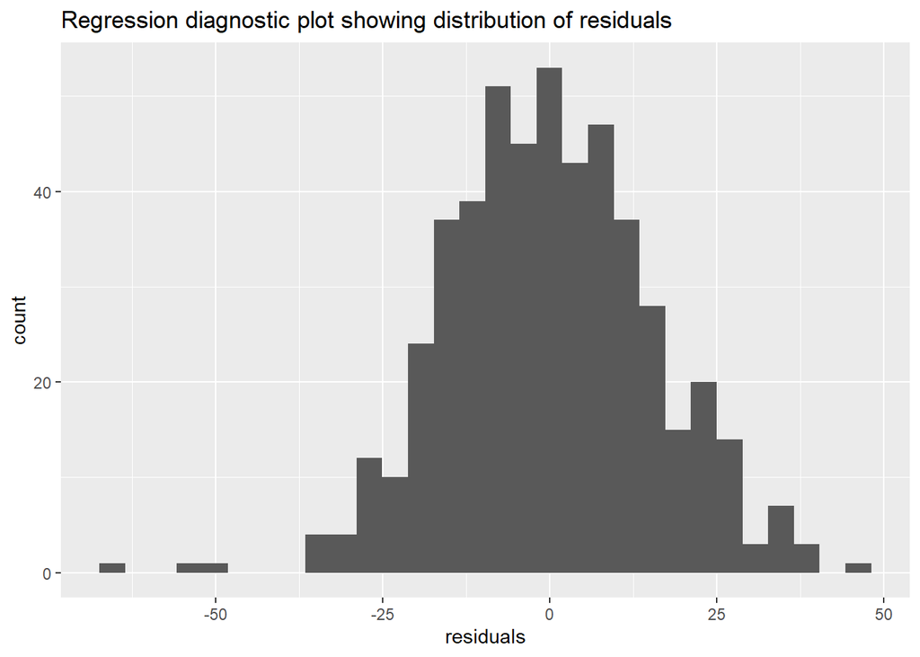

```r
model_fit <- lm(y~ x, data = sim_df)

sim_df %>%
  mutate(fitted_values = predict(model_fit, sim_df),
         residuals = y - fitted_values) %>%
  ggplot(aes(residuals)) +
  geom_histogram() +
  labs(x = "residuals",
       title = "Regression diagnostic plot showing distribution of residuals")
```

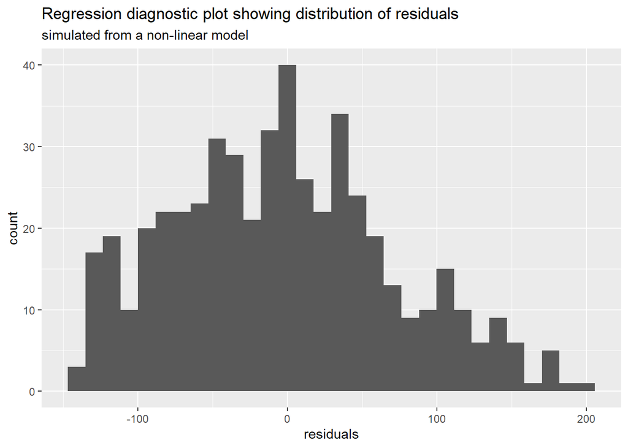

```r
sim_nonlinear_df %>%
  mutate(fitted_values = predict(model_fit_nonlin, sim_df),
         residuals = y - fitted_values) %>%
  ggplot(aes(residuals)) +
  geom_histogram() +
  labs(x = "residuals",
       title = "Regression diagnostic plot showing distribution of residuals",
       subtitle = "simulated from a non-linear model")
```

We can also generate quantile quantile plots

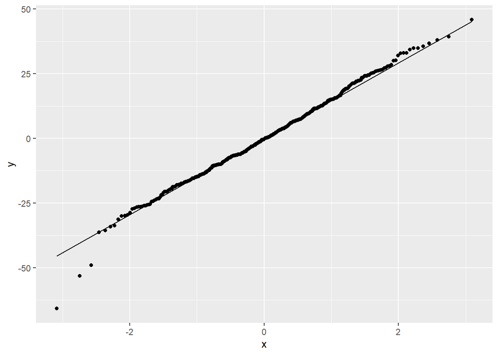

```r
sim_df %>%
  mutate(fitted_values = predict(model_fit, sim_df),
         residuals = y - fitted_values) %>%
  ggplot(aes(sample = residuals))+
  stat_qq() +
  stat_qq_line()
```

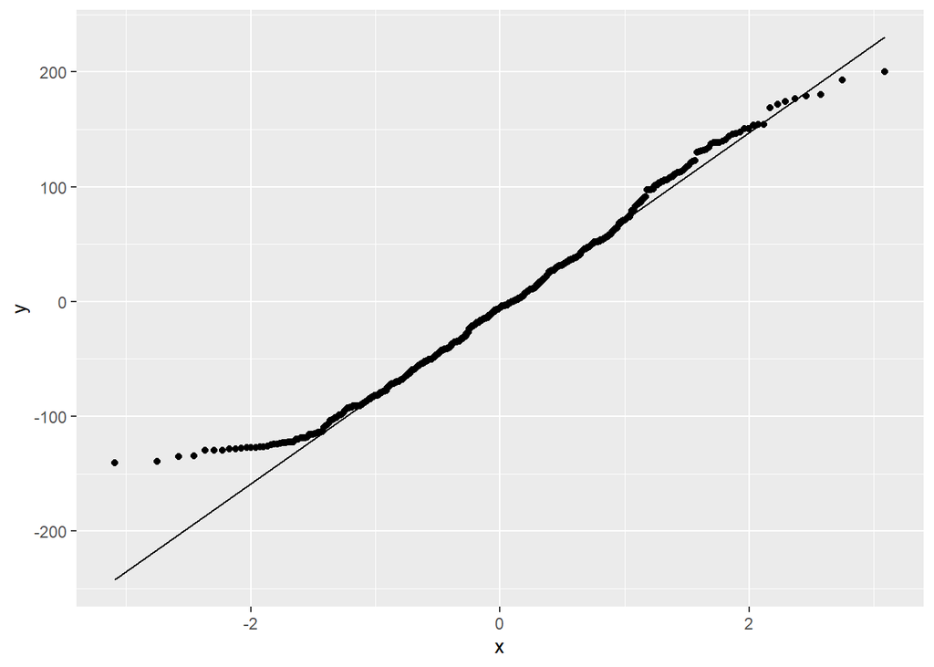

```r
sim_nonlinear_df %>%
  mutate(fitted_values = predict(model_fit_nonlin, sim_df),
         residuals = y - fitted_values) %>%
  ggplot(aes(sample = residuals))+
  stat_qq() +
  stat_qq_line()
```

We can also formally test the normality of residuals with a **shapiro-wilks test**

```r
shapiro.test(resid(model_fit))
```

```
##
##  Shapiro-Wilk normality test
##
## data:  resid(model_fit)
## W = 0.99353, p-value = 0.03071
```

```r
shapiro.test(resid(model_fit_nonlin))
```

```
##
##  Shapiro-Wilk normality test
##
## data:  resid(model_fit_nonlin)
## W = 0.98994, p-value = 0.001692
```

## Models with more than one input

Let’s return to our height/weight example and add another input variable

```r
multi_lm <- lm(weight ~ height + male, data = earn)
sjPlot::tab_model(multi_lm)
```

|  | weight |  |  |
| --- | --- | --- | --- |
| Predictors | Estimates | CI | p |
| (Intercept) | -107.07 | -138.83 – -75.30 | **<0.001** |
| height | 3.89 | 3.40 – 4.38 | **<0.001** |
| male | 11.84 | 7.94 – 15.73 | **<0.001** |
| Observations | 1789 |  |  |
| R<sup>2</sup> / R<sup>2</sup> adjusted | 0.315 / 0.314 |  |  |

How do we interpret the coefficients?

- The intercept is the expected weight of a female with a height of zero (not very helpful).
- The height coefficient interpretation is, for two people of the same sex, but who differ by one inch, there is an expected increase of 3.89 pounds.
- The male coefficient states that for two people who have the same height, a male is expected to weigh 11.84 pounds more than a female.

What if I interpret this model to say: If I can an inch in height, I should expect to weigh 3.89 more pounds. Is this correct?

NO! The model coefficients are interpreted between people. This is not a within person model.

### Prediction with confidence intervals

We can add an argument to our predict method to get predictions with confidence intervals. Let’s generate a prediction for a 70 inch male.

```r
new_data <- data.frame(height = 70, male = 1)
predict(multi_lm, newdata = new_data, interval = "confidence", level = .95)
```

```
##       fit      lwr      upr
## 1 176.924 174.7588 179.0893
```

We would expect them to weigh 176.924 with a 95% confidence interval of 174.7588 to 179.0893.

### Centering predictors

Our intercept isn’t very helpful in it’s current state. Let’s center this variable by subtracting its mean, and then re-running the regression.

```r
earn <- earn %>%
  mutate(height_center = height - mean(height))
multi_lm <- lm(weight ~ height_center + male, data = earn)
sjPlot::tab_model(multi_lm)
```

|  | weight |  |  |
| --- | --- | --- | --- |
| Predictors | Estimates | CI | p |
| (Intercept) | 151.75 | 149.77 – 153.72 | **<0.001** |
| height_center | 3.89 | 3.40 – 4.38 | **<0.001** |
| male | 11.84 | 7.94 – 15.73 | **<0.001** |
| Observations | 1789 |  |  |
| R<sup>2</sup> / R<sup>2</sup> adjusted | 0.315 / 0.314 |  |  |

Our height and male coefficients have not changed, however our intercept now makes a lot more sense. It’s interpretation is now:

- The expected weight for a non-male of average height

Let’s add the ethnicity variable to this model

```r
earn <- earn %>%
  mutate(height_center = height - mean(height))
multi_lm2 <- lm(weight ~ height_center + male + factor(ethnicity), data = earn)
sjPlot::tab_model(multi_lm2)
```

|  | weight |  |  |
| --- | --- | --- | --- |
| Predictors | Estimates | CI | p |
| (Intercept) | 156.52 | 152.08 – 160.96 | **<0.001** |
| height_center | 3.85 | 3.36 – 4.35 | **<0.001** |
| male | 12.11 | 8.19 – 16.02 | **<0.001** |
| ethnicity [Hispanic] | -6.15 | -13.13 – 0.82 | 0.084 |
| ethnicity [Other] | -12.26 | -22.43 – -2.09 | **0.018** |
| ethnicity [White] | -5.19 | -9.64 – -0.74 | **0.022** |
| Observations | 1789 |  |  |
| R<sup>2</sup> / R<sup>2</sup> adjusted | 0.318 / 0.316 |  |  |

Notice how we now have 3 more coefficients, not just one. Also remember that the ethnicity variable has 4 values, not 3 (Black, Hispanic, White, Other). The function `factor()` has chosen a reference alphabetically.

What are the interpretations of these coefficients?

### Fit statistics

In class we talked about $R^2$ and how it can be used to understand explained variance in a model. We also looked at how we can artificially inflate it by adding more variables. Let’s do a short simulation study to look at this. Below I build a data set that has 300 variables that are randomly generated from a standard normal distribution ($N(0, 1)$). The outcome y has the same distribution. Therefore, there should be no relationship between and X variable and the y variable.

We are going to, successively, build models adding one variable at a time, and save both the r-squared and the adjusted r-squared.

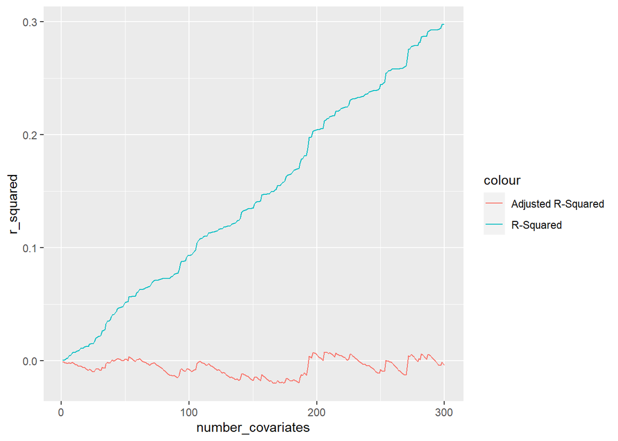

```r
n_row <- 1000
n_col <- 300
y <- rnorm(n_row)

X <- matrix(data = NA, nrow = n_row, ncol = n_col, byrow = FALSE,
            dimnames = NULL)
for(i in 1:n_col) {
  X[,i] <- rnorm(n_row)
}

r_squared_sim  <- purrr::map_df(1:n_col, function(x) {
   model_fit <- lm(y ~ X[, 1:x])
   tibble(number_covariates = x,
          r_squared = summary(model_fit)$r.squared,
          adj_r_squared = summary(model_fit)$adj.r.squared)
})

r_squared_sim %>%
  ggplot(aes(number_covariates, r_squared, col = "R-Squared")) +
  geom_line()+
  geom_line(aes(number_covariates, adj_r_squared, col = "Adjusted R-Squared"))
```

We can see how the $R^2$ is increased every time we add a variable (which is unrelated to the outcome!), while the adjusted $R^2$ remains low